# Navegando na IMDb: Análise exploratória

Proposta de variáveis e estudo preliminar de viabilidade

André Bispo - 09.11.2020

## Proposta

Buscando inferir sobre a viabilidade econômica para a produção de um filme cinematográfico que seja tanto um sucesso financeiro, quanto um sucesso de crítica, essa proposta apresenta a seleção a seguir, elaborada a partir da base de dados da IMDb com 3713 títulos de filmes lançados desde 1916.

Estão relacionados nos quadros abaixo aqueles onde que se identificou ao menos uma ocorrência acima dos limites de corte estabelecidos nessa propostade para o lucro (US$100.000.000) e ano (a partir do ano 2000), além da verificação dos critérios de seleção destacados abaixo (vide *Levantamento realizado*).

Do ponto de vista operacional, a média de custo de produção dos filmes listados conforme os critérios desta proposta é de US$ 133.692.308, valor estimado e que pode ser considerado como base para efeito de planejamento. Existindo interesse, é possível realizar trabalho de verificação mais apurado, identificando os custos de produção relacionados com cada um dos profissionais e características de interesse, individualmente e combinados.

Os nomes destacados em **azul** são os que apresentam mais de uma ocorrência de relação positiva com os critérios de seleção e corte (lucro e ano) aqui adotados e os nomes em **preto**, à excessão dos filmes da categoria drama, apresentam pelo menos uma ocorrência:

1. Para a seleção dos diretores, Christopher Nolan e Peter Jackson são os diretores com mais filmes de sucesso em público (US$) e crítica (avaliação IMDb e Likes Facebook).

**Quadro 1:** Listagem dos diretores com um ou mais filmes de sucesso em crítica e público para os filmes da base da IMDb.

| Diretor |  |  |  |  |
| --- | --- | --- | --- | --- |
| Christopher Nolan | Peter Jackson | Joss Whedon | David Fincher | Ridley Scott |

2. A seleção de atores principais, coadjuvantes e terceiros atores relaciona nos quadros abaixo os atores, em ordem decrescente de relevância em relação aos critérios deste trabalho.

**Quadro 2:** Listagem dos atores com um ou mais filmes de sucesso em crítica e público para os filmes da base da IMDb.

| Ator Principal |  |  |  |  |  |
| --- | --- | --- | --- | --- | --- |
| Matt Damon | Chris Hemsworth | Leonardo DiCaprio | Aidan Turner | Patrick Fugit | Tom Hardy |

| Ator Coadjuvante |  |  |  |  |  |
| --- | --- | --- | --- | --- | --- |
| Christian Bale | Robert Downey Jr. | Adam Brown | Donald Glover | Sela Ward | Tom Hardy |

| Terceiro Ator |  |  |  |  |  |
| --- | --- | --- | --- | --- | --- |
| Joseph Gordon-Levitt | Scarlett Johansson | Anne Hathaway | Benedict Wong | Emily Ratajkowski | James Nesbitt |

3. Com relação à classificação, os filmes destinados para a faixa etária de 13 anos em diante foram os que obtiveram maior sucesso em público e crítica.

**Quadro 3:** Listagem das classificações etárias com um ou mais filmes de sucesso em crítica e público para os filmes da base da IMDb.

| Classificação |  |
| --- | --- |
| A partir de 13 anos | A partir de 18 anos |

4. Com relação à categoria dos filmes, os títulos de ação são os de maior sucesso de público e crítica, seguidos pelos filmes de aventura e ficção científica. Optou-se por não destacar os filmes de drama devido a proporção elevada de filmes fora dos critérios de seleção (vide Figura 2).

**Quadro 4:** Listagem das categorias de filmes agrupadas com um ou mais filmes de sucesso em crítica e público para os filmes da base da IMDb.

| Categoria |  |  |  |  |  |  |
| --- | --- | --- | --- | --- | --- | --- |
| Action\|Adventure\|Sci-Fi | Drama | Action\|Adventure\|Sci-Fi\|Thriller | Action\|Thriller | Adventure\|Drama\|Sci-Fi | Adventure\|Fantasy | Crime\|Drama\|Mystery\|Thriller |

- A seleção encontra-se em ordem decrescente de relevância em relação aos critérios definidos nessa análise exploratória.
- Com base nas informações obtidas no levantamento realizado, a sugestão de produção mais alinhada com a demanda em questão pode ser obtida pela combinação dos profissionais e demais itens da listagem apresentada.

### Levantamento realizado

##### Etapa 1 - Definição dos critérios de seleção.

Também conhecida como Internet Movie Database, a IMDb é uma base de dados online de informação sobre música, cinema, filmes, programas e comerciais para televisão e jogos de computador[^1].

Os dados das produções cinematográficas do período de 1916 a 2016 da IMDb foram utilizados, destacando-se as seguintes características (Fig. 1) para o levantamento e tomada de decisões preliminares sobre a realização do filme:

1. Faixa de duração (140 a 200 minutos);
2. Notas IMDb acima de 7,5 pontos;e
3. Número de *likes* do *Facebook* acima de 90.000.

**Figura 1:** Relação entre o lucro e a duração, avaliação IMDb e quantidade de *likes do Facebook* dos filmes

[figure not shown]

- Com base nos dados dos gráficos de dispersão gerados, identificou-se as características listadas anteriormente, nas quais os filmes com maior lucratividade se assentam:
- Na sequência, foi realizada a verificação desses parâmetros indicativos por meio dos histogramas, de forma a se tentar identificar os filmes que apresentavam uma menor ocorrência de prejuízo, maior ocorrência de manutenção do capital empregado e, melhor, uma **maior possibilidade de lucro**.

#### Etapa 2 - Seleção dos profissionais e das características técnicas associadas a filmes de sucesso.

Para a escolha dos profissionais, classificação e categorias dos filmes, além dos critérios definidos na etapa anterior, foi estabelecido o ano 2000 como o limite de corte para a escolha. Essa definição foi arbitrária e adotou razão de ordem prática em função do tempo decorrido e a relação do mesmo com a eventual impossibilidade de convidar atores e diretores anteriores ao ano limite (2000), bem como as mudanças das preferências do público ao longo do tempo.

Definido esse marco temporal para o limite inferior da seleção, o resultado final foi obtido com base nas figuras abaixo, da análise das variáveis analisadas, a saber, listagem dos diretores, atores principais, coadjuvantes e dos terceiros atores, bem como a classificação e categorização dos filmes, adotando-se as etapas listadas a seguir:

1. uma filtragem da base de dados com os critérios identificados na Etapa 1 deste;
2. identificação dos diretores, atores, classificação e categorias que se enquadravam nesses critérios;
3. uma nova seleção a partir dessa base de dados filtrada, identificando o número de filmes dessas listas com lucro acima de US$ 100.000.000.

A Figura 2 resume a análise para a definição da listagem final visando a realização do filme e identifica o quantitativo de filmes com lucro acima de US$ 100.000.000 tendo por base as variáveis desejadas e os critérios estabelecidos na etapa anterior:

**Figura 2:** Identificação dos profissionais e características técnicas desejáveis para um filme de sucesso de público e crítica.

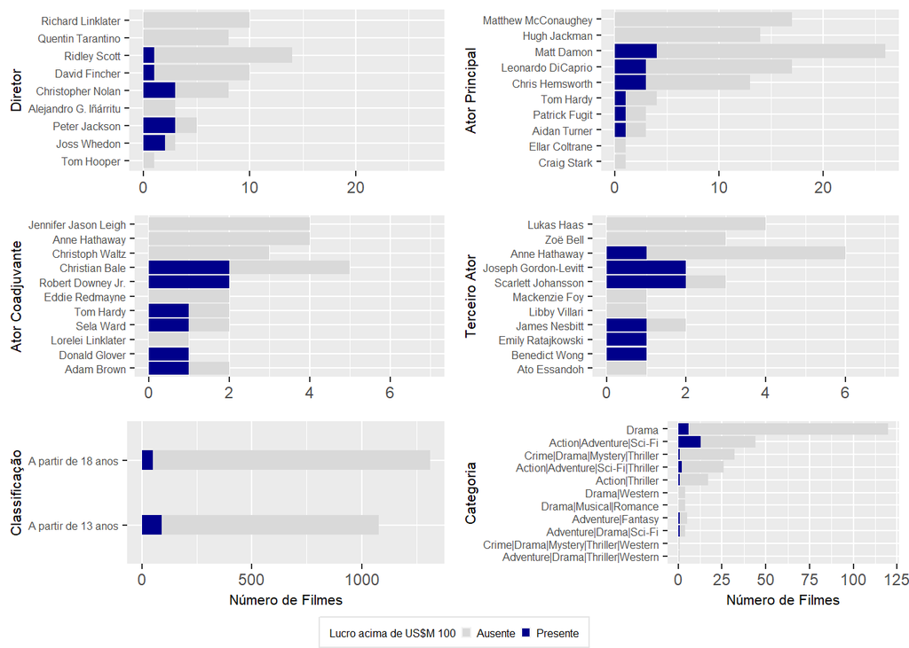

#### Considerações finais e estimativa de custos de produção

Ressalva-se que essa proposta é uma análise indicativa, elaborada para filtrar as informações e facilitar um trabalho de avaliação da viabilidade econômica e técnica mais aprofundado.

É interessante destacar que as informações consolidadas na Figura 2 permitem visualizar a relação entre a produção e o retorno financeiro de alguns profissionais, existindo atores com relação muito favorável entre atuação e sucesso.

[^1]: https://pt.wikipedia.org/wiki/IMDb